# The reticulate Package

Dr. Alfredo Hernandez Sanchez

4/2/2021

## Python in R Markdown

The following is a short guide for using Python in R Markdown using the `reticulate` package and the `use_python()` command. This assumes that you do not have Python installed (or at least Python 3) yet.

Before we begin, go over following steps:

- Download the [miniconda](https://docs.conda.io/en/latest/miniconda.html) Python distribution
- Install the `reticulate` package in R
- Find the folder (in your computer) where you installed `miniconda3`

Now let’s load `reticulate` and find the version of Python we want to use. Then we load the Python interpreter for our R session.

```r
#Load the reticulate package
library(reticulate)
#Find the miniconda3
use_python("C:/Users/alhdz/miniconda3", required = T)
#Load the Python shell
repl_python()
```

Let’s check which version of python we are using.

```r
#Inspect the Python version
py_config()
```

```
## python:         C:/Users/alhdz/miniconda3/python.exe
## libpython:      C:/Users/alhdz/miniconda3/python39.dll
## pythonhome:     C:/Users/alhdz/miniconda3
## version:        3.9.1 (default, Dec 11 2020, 09:29:25) [MSC v.1916 64 bit (AMD64)]
## Architecture:   64bit
## numpy:          C:/Users/alhdz/miniconda3/Lib/site-packages/numpy
## numpy_version:  1.19.2
## sys:            [builtin module]
##
## NOTE: Python version was forced by use_python function
```

To run Python code, chunks should be named *python* rather than *r*. You can use the **Insert** option in the top right corner of the RStudio *editor window* and select the `Python` option. It is important to remember that objects that are loaded into the Python environment will not show up in your RStudio *environment window*. Similarly, if you type `repl_python()` in your console, you will notice that when it expecting Python code, you will see `>>>` rather than `>`, you can go back to R by typing `exit`.

Let’s make an example. If you try the syntax below in an `r` chunk, it will not run! In a `python` chunk however:

```python
a="Hello"+" World"
print(a)
```

```
## Hello World
```

## Python Libraries

Now let’s install some libraries for Python, these are like packages in R. Let’s run the **Anaconda Prompt (miniconda3)** and type `conda install seaborn` then write `pip install -U scikit-learn` to install scikit-learn. The former is a data visualization library (similar to `ggplot2`) and the latter a machine learning library.

Now, let’s load the libraries we just installed. We can use R syntax in an `r` chunk, for example:

```r
sklearn <- import('sklearn')
sklearn
```

```
## Module(sklearn)
```

We also can use the Python syntax in a `python` chunk. Let’s do some troubleshooting that is common for Markdown Python plots in Windows.

```python
#Sometimes R Markdown has trouble finding some plotting plugins!
import os
os.environ['QT_QPA_PLATFORM_PLUGIN_PATH'] = 'C:/Users/alhdz/miniconda3/Library/plugins/platforms'
```

## Penguins with `seaborn`

Now lets `import` seaborn using Python syntax and use the Palmer Penguins data set to make a histogram.

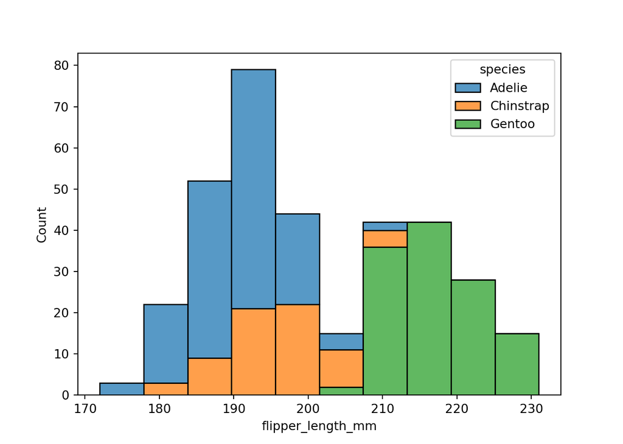

```python
import seaborn as sns
df = sns.load_dataset("penguins")
sns.histplot(data=df, x="flipper_length_mm", hue="species", multiple="stack")
```

## Penguins with `ggplot2`

Finally, let’s do the same thing, but this time with `ggplot2` and R syntax.

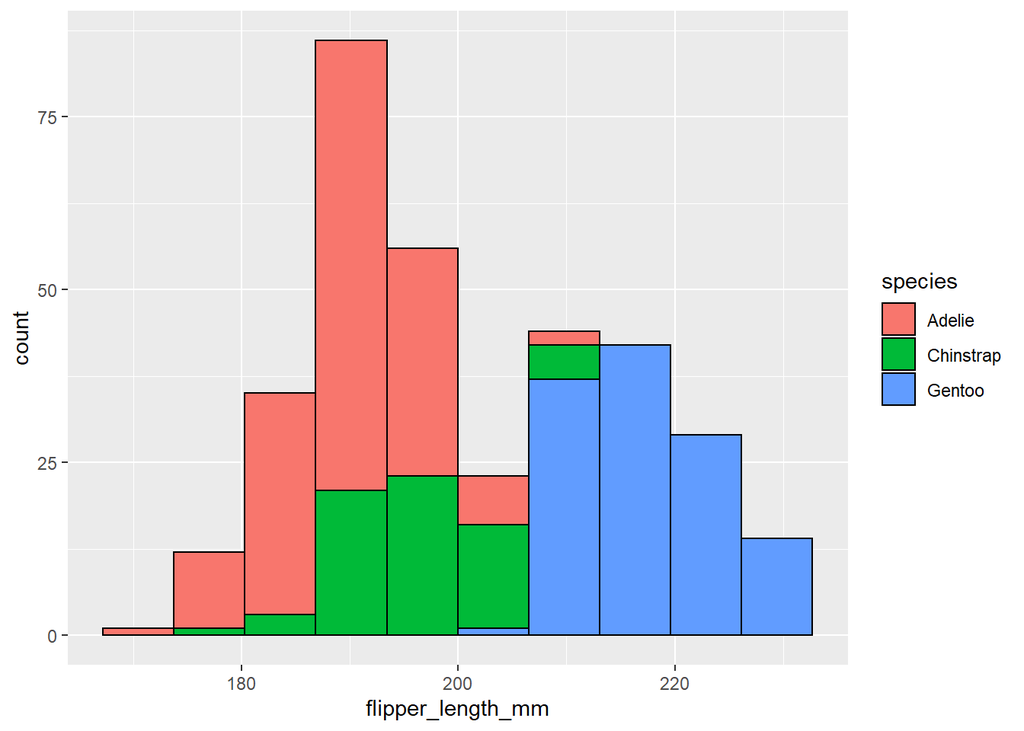

```r
library(palmerpenguins) #you may need to install!
library(tidyverse)
df <- data.frame(penguins)

df %>%
    ggplot(aes(x=flipper_length_mm, fill=species)) +
    geom_histogram(color="black", bins = 10)
```